# Conodont Permian/Triassic

## IV. Assess the sampling effort

Species accumulation curves are performed to estimate the sampling effort of each region, at a global time scale, then at the stage/substage level. Samples are species within sections. Regions that include less than 3 sections as well as regions with only one species are excluded from further analyses because they do not hold enough data according to *iNEXT* R package. Graphic representations include the accumulation curves and the sampling coverage, provided by *iNEXT* outputs.

```r
#Graphical functions
SAC.graph <- #plot species accumulation curve
  function(data, xmax, xseq, ymax, yseq){
    g <- iNEXT::ggiNEXT(data,facet.var="Assemblage")+
      theme_bw()+
      scale_color_manual(values = viridis(1))+
      scale_fill_manual(values = viridis(1))+
      scale_x_continuous(breaks=seq(0,xmax,xseq))+
      scale_y_continuous(breaks=seq(0,ymax,yseq),limits=c(0,ymax), expand=c(0,0))+
      theme(legend.position="bottom",
            text=element_text(size=8),
            legend.title=element_text(size=8),
            legend.text=element_text(size=8),
            axis.title=element_text(size=8),
            axis.text=element_text(size=8))
    labs(y = "Species richness", x = "Number of sections")
    #svg(filename = "SAC_Regions.svg", width = 18, height = 3.5)
    g
    #dev.off()
  }

SC.graph <- #plot sampling coverage
  function(data, xmax, xseq){
    # data.i <- lapply(data$iNextEst$size_based, function(data){data %>% filter(method=="observed")})
    # data.df <- do.call(rbind.data.frame, data.i)
    data.df <- data$iNextEst$size_based %>% filter(Method=="Observed")

    g <- ggplot2::qplot(data=data.df, x=t, y=SC, label=Assemblage)+
      geom_point()+
      geom_errorbar(aes(ymin=SC.LCL, ymax=SC.UCL),linewidth=0.5)+
      geom_text_repel(aes(label=data.df$Assemblage),size=3)+
      scale_y_continuous(breaks=seq(0,1,0.1), limits=c(0,1.01), expand=c(0,0))+
      scale_x_continuous(breaks=seq(0,xmax,xseq), limits=c(0,xmax), expand=c(0,0))+
      theme_bw()+
      theme(text=element_text(size=8),
            legend.title=element_text(size=8),
            legend.text=element_text(size=8),
            axis.title=element_text(size=8),
            axis.text=element_text(size=8))+
      labs(x="Number of sections", y="Sampling coverage")
    g
  }
```

### IV.a) Global species accumulation curve

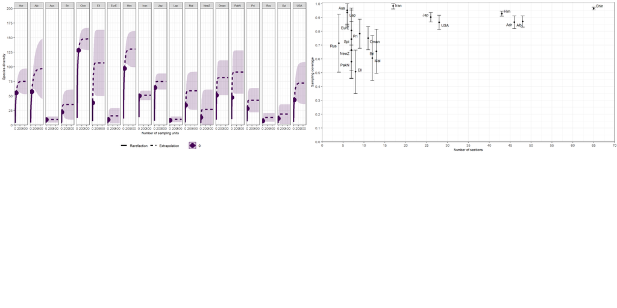

```r
Regions.un2 <- Regions %>% #Remove regions with one or two regions
  select(Section,Region) %>% unique() %>%
  group_by(Region) %>% summarise(Nombre =n()) %>%
  filter(Nombre%in%c(1,2)) %>% droplevels() %>%
  dplyr::pull(Region)

data.SAC <- Occ.NT.2022.clean.regions %>% select(Gn_Species_current,Section,Region) %>%
  filter(!Region %in% Regions.un2) %>%
  droplevels() %>% unique()
list.data.SAC <- split(data.SAC, data.SAC$Region, drop=TRUE)
list.data.SAC <- lapply(list.data.SAC, function(data){data %>% select(-Region) %>% droplevels()})
list.data.SAC <- lapply(list.data.SAC, function(data){as.data.frame.matrix(table(data$Gn_Species_current, data$Section))})

num.row <- unlist(lapply(list.data.SAC, nrow))
num.row.1 <- which(num.row>1)
list.data.SAC <- list.data.SAC[c(num.row.1)]#Remove regions with only one species occurrence

i1 <- iNEXT::iNEXT(list.data.SAC, datatype = "incidence_raw", endpoint=500)
SAC.analysis <- SAC.graph(i1, xmax=500, xseq=200, ymax=200, yseq=25)
SC.analysis <- SC.graph(i1, xmax=70, xseq=5)
ggarrange(SAC.analysis, SC.analysis, col=1, row=2)
```

```r
svg(filename = "Species accumulation curve.svg", width = 12, height=3)
SAC.analysis
dev.off()
```

```r
svg(filename = "Sampling coverage.svg", width = 6.3, height=4)
SC.analysis
dev.off()
```

## V. Build incidence matrices

```r
data.SAC.time <- Occ.NT.2022.clean.regions %>%
  select(Gn_Species_current,Section,Region,Stage,Sub_stage) %>% droplevels() %>%
  mutate(Sub_stage=recode(Sub_stage, 'Upper' = 'Changhsingian', 'Late'= 'Changhsingian', 'Lower'='Changhsingian'),
         Sub_stage = coalesce(Sub_stage, Stage)) %>% select(!Stage) %>%
  droplevels() %>% unique()

list.data.SAC.time <- #build a nested list by time, then region
  purrr::reduce(.x = list(~Sub_stage, ~Region),
                .f = ~ map_depth(.x, .depth = pluck_depth(.x) - 2,  split, .y),
                .init = data.SAC.time)

list.data.SAC.time.full <- #remove absent region from each time interval
  lapply(list.data.SAC.time, function(data){
    purrr::discard(data, function(x) is_empty(x$Section))
  })
list.data.SAC.time.full <- #remove useless factors
  lapply(list.data.SAC.time.full, function(data){
    purrr::map(data,~{.x %>%
        select(-Region, -Sub_stage) %>%
        droplevels()})})


list.data.SAC.time.up2 <- #keep only regions with more than 2 sections
  lapply(list.data.SAC.time.full, function(data){
           l <- list()
           for (i in 1:length(data)) {
             if (nlevels(as.factor(data[[i]]$Section))>2)
               l <- c(l, data[i])
           }
           data <- l
         })
list.data.SAC.time.up2.occ <- #Occurrence matrix
  lapply(list.data.SAC.time.up2, function(data){
    purrr::map(data, function(x){as.data.frame.matrix(table(x$Gn_Species_current, x$Section))})
  })
list.data.SAC.time.up2.occ2 <- #Remove regions with only one species
  lapply(list.data.SAC.time.up2.occ, function(data){
    num.row <- unlist(lapply(data, nrow))
    num.row.up1 <- which(num.row>1)
    data <- data[c(num.row.up1)]
  })
list.data.SAC.time.up2.occ2 <- list( #Arrange the dataset
  Changhsingian = list.data.SAC.time.up2.occ2$Changhsingian,
  Griesbachian = list.data.SAC.time.up2.occ2$Griesbachian,
  Dienerian = list.data.SAC.time.up2.occ2$Dienerian,
  Smithian = list.data.SAC.time.up2.occ2$Smithian,
  Spathian = list.data.SAC.time.up2.occ2$Spathian
  )
```

```r
#Function for dividing datasets depending on singletons
Remove_single <- function(data){
  data <- data %>% mutate(Somme = rowSums(data), RowNames = rownames(data)) %>% filter(Somme != 1)
  rownames(data) <- data$RowNames
  data <- data %>% select(-Somme, -RowNames)
}

#Without regions < 2 sections
list.occ.up2 <- split(data.SAC.time, data.SAC.time$Sub_stage)
list.occ.up2 <- lapply(list.occ.up2, droplevels)

list.occ.up2$Changhsingian <- list.occ.up2$Changhsingian %>%
  filter(Region %in% c(names(list.data.SAC.time.up2$Changhsingian))) %>%
  droplevels()
list.occ.up2$Griesbachian <- list.occ.up2$Griesbachian %>%
  filter(Region %in% c(names(list.data.SAC.time.up2$Griesbachian))) %>%
  droplevels()
list.occ.up2$Dienerian <- list.occ.up2$Dienerian %>%
  filter(Region %in% c(names(list.data.SAC.time.up2$Dienerian))) %>%
  droplevels()
list.occ.up2$Smithian <- list.occ.up2$Smithian %>%
  filter(Region %in% c(names(list.data.SAC.time.up2$Smithian))) %>%
  droplevels()
list.occ.up2$Spathian <- list.occ.up2$Spathian %>%
  filter(Region %in% c(names(list.data.SAC.time.up2$Spathian))) %>%
  droplevels()

list.occ.up2 <- #remove useless factors
  lapply(list.occ.up2, function(data){
    data %>% select(-Section, -Sub_stage) %>%
      unique() %>% droplevels()
  })

list.contingence.up2 <- lapply(list.occ.up2, function(data){
  as.data.frame.matrix(table(data$Gn_Species_current, data$Region))
})
list.contingence.up2 <- list.contingence.up2[c("Changhsingian","Griesbachian","Dienerian","Smithian","Spathian")]

list.contingence.up2.single <- list.contingence.up2
list.contingence.up2.Nosingle <- lapply(list.contingence.up2, Remove_single)
list.contingence.up2.Nosingle <- lapply(list.contingence.up2.Nosingle, droplevels)

# write.csv2(list.contingence.up2.Nosingle$Changhsingian, file="Conodont_incidence matrix_no singleton_Changhsingian.csv")
# write.csv2(list.contingence.up2.Nosingle$Griesbachian, file="Conodont_incidence matrix_no singleton_Griesbachian.csv")
# write.csv2(list.contingence.up2.Nosingle$Dienerian, file="Conodont_incidence matrix_no singleton_Dienerian.csv")
# write.csv2(list.contingence.up2.Nosingle$Smithian, file="Conodont_incidence matrix_no singleton_Smithian.csv")
# write.csv2(list.contingence.up2.Nosingle$Spathian, file="Conodont_incidence matrix_no singleton_Spathian.csv")
```

## VI. Multivariate analyses

### VI.a) ORP analyses

The ORP and associated graphical R functions have their own GitHub repository: https://github.com/PaulineGnsr/ORP_analysis

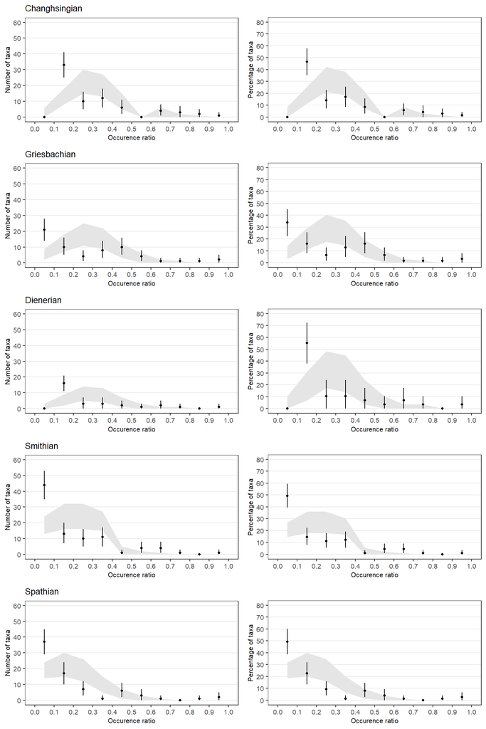

```r
list.ORP.up2 <-list(
  Changhsingian = list(Changhsingian = as.data.frame(t(list.contingence.up2.single$Changhsingian)),
                       name = "Changhsingian"),
  Griesbachian = list(Griesbachian = as.data.frame(t(list.contingence.up2.single$Griesbachian)),
                      name = "Griesbachian"),
  Dienerian = list(Dienerian = as.data.frame(t(list.contingence.up2.single$Dienerian)),
                   name = "Dienerian"),
  Smithian = list(Smithian = as.data.frame(t(list.contingence.up2.single$Smithian)),
                  name = "Smithian"),
  Spathian = list(Spathian = as.data.frame(t(list.contingence.up2.single$Spathian)),
                  name = "Spathian")
)


ORP <- function(data, Nite, right){

  #Empiric ORP
  n.sp <- as.numeric(ncol(data[[1]]))
  #n.region <- as.numeric(nrow(data[[1]]))

  perc <- apply(data[[1]], 2, function(x)sum(x)/length(x)*100)
  hist.perc <- hist(perc, breaks=seq(0,100,10), right=right, plot=FALSE)
  df.perc <- data.frame("hist.perc.counts"=as.numeric(hist.perc$counts),
                        "hist.perc.perc"=apply(as.data.frame(hist.perc$counts), 1,
                                               function(x)x/n.sp*100),
                        row.names = hist.perc$mids/100)


  #A function for CI and null model
  l.boot <- lapply(vector("list",Nite), function(x){sample(data[[1]], replace = TRUE)})
  l.lot <- lapply(vector("list",Nite), function(x){apply(data[[1]],1,function(x)sample(x))})

  df.boot <- #Boostrap
    lapply(l.boot, function(data){
      perc.boot <- as.numeric(apply(data, 2, function(x)sum(x)/length(x)*100))
      hist.perc.boot <- hist(perc.boot, breaks=seq(0,100,10), right=right, plot=FALSE)

      hist.perc.boot.count <- hist.perc.boot$counts
      hist.perc.boot.perc <- apply(as.data.frame(hist.perc.boot$count), 1,
                                   function(x)x/n.sp*100)

      list(hist.perc.boot.count, hist.perc.boot.perc)

    }
    )

  df.boot.count <-
    as.data.frame(lapply(df.boot, function(data){data[[1]]}),
                  col.names = 1:length(l.boot),
                  row.names = seq(0.05,0.95,0.10)
    )
  df.boot.perc <-
    as.data.frame(lapply(df.boot, function(data){data[[2]]}),
                  col.names = 1:length(l.boot),
                  row.names = seq(0.05,0.95,0.10)
    )


  df.lot <- #Lottery
    lapply(l.lot, function(data){
      perc.lot <- as.numeric(apply(t(data), 2, function(x)sum(x)/nrow(t(data))*100))
      hist.lot <- hist(perc.lot, breaks=seq(0,100,10), right=right, plot=FALSE)

      hist.lot.count <- hist.lot$counts
      hist.lot.perc <- apply(as.data.frame(hist.lot$counts), 1,
                             function(x)x/n.sp*100)

      list(hist.lot.count, hist.lot.perc)
    }
    )
  df.lot.count <-
    as.data.frame(lapply(df.lot, function(data){data[[1]]}),
                  col.names = 1:length(l.boot),
                  row.names = hist.perc$mids/100
    )
  df.lot.perc <-
    as.data.frame(lapply(df.lot, function(data){data[[2]]}),
                  col.names = 1:length(l.boot),
                  row.names = hist.perc$mids/100
    )

  #LowerBound and UpperBound
  CI.count.min <- as.numeric(apply(df.boot.count,1,function(x)sort(as.numeric(x))[0.025*Nite]))
  CI.count.max <- as.numeric(apply(df.boot.count,1,function(x)sort(as.numeric(x))[0.975*Nite]))
  CI.perc.min <- as.numeric(apply(df.boot.perc,1,function(x)sort(as.numeric(x))[0.025*Nite]))
  CI.perc.max <- as.numeric(apply(df.boot.perc,1,function(x)sort(as.numeric(x))[0.975*Nite]))

  lot.count.min <- as.numeric(apply(df.lot.count,1,function(x)sort(as.numeric(x))[0.025*Nite]))
  lot.count.max <- as.numeric(apply(df.lot.count,1,function(x)sort(as.numeric(x))[0.975*Nite]))
  lot.perc.min <- as.numeric(apply(df.lot.perc,1,function(x)sort(as.numeric(x))[0.025*Nite]))
  lot.perc.max <- as.numeric(apply(df.lot.perc,1,function(x)sort(as.numeric(x))[0.975*Nite]))

  #Gather all results
  df.ORP <- cbind (df.perc,
                   CI.count.min, CI.count.max, CI.perc.min, CI.perc.max,
                   lot.count.min, lot.count.max, lot.perc.min, lot.perc.max)
  #print(df.ORP)

  #Graphic representation
  #Taxa count
  plot.count <-
    ggplot(df.ORP, aes(x=as.numeric(rownames(df.ORP)), y=hist.perc.counts))+
    geom_ribbon(aes(ymin=lot.count.min, ymax=lot.count.max),fill="grey90")+
    geom_errorbar(aes(ymin=CI.count.min, ymax=CI.count.max), width=0) +
    geom_point(size=1)+
    theme_bw()+
    theme(text=element_text(size=8),
          legend.title=element_text(size=8),
          legend.text=element_text(size=8),
          axis.title=element_text(size=8),
          axis.text=element_text(size=8),
          plot.title = element_text(size=10),
          panel.grid.major.x = element_blank(),
          panel.grid.minor.x = element_blank(),
          panel.grid.minor.y = element_blank())+
    scale_y_continuous(breaks=seq(0,60,10),limits=c(0,60))+
    scale_x_continuous(breaks=seq(0,1,0.1),limits=c(0,1))+
    labs(x="Occurence ratio", y="Number of taxa", title=data[[2]])

  #Taxa perc
  plot.perc <-
    ggplot(df.ORP, aes(x=as.numeric(rownames(df.ORP)), y=hist.perc.perc))+
    geom_ribbon(aes(ymin=lot.perc.min, ymax=lot.perc.max),fill="grey90")+
    geom_errorbar(aes(ymin=CI.perc.min, ymax=CI.perc.max), width=0) +
    geom_point(size=1)+
    theme_bw()+
    theme(text=element_text(size=8),
          legend.title=element_text(size=8),
          legend.text=element_text(size=8),
          axis.title=element_text(size=8),
          axis.text=element_text(size=8),
          panel.grid.major.x = element_blank(),
          panel.grid.minor.x = element_blank(),
          panel.grid.minor.y = element_blank())+
    scale_y_continuous(breaks=seq(0,80,10),limits=c(0,80))+
    scale_x_continuous(breaks=seq(0,1,0.1),limits=c(0,1))+
    labs(x="Occurence ratio", y="Percentage of taxa", title="")

  ggarrange(plot.count, plot.perc)

}

multi.ORP <- lapply(list.ORP.up2, ORP, Nite=9999, right=TRUE)
plot.ORP <- ggarrange(plotlist=multi.ORP,ncol=1,nrow=5)
plot.ORP
```

```r
ggsave(file="ORP_conodont.svg", plot=plot.ORP,
       width = 160, height = 247 , units="mm")
```

### VI.b) Ordination analyses (PCoA and UPGMA classification)

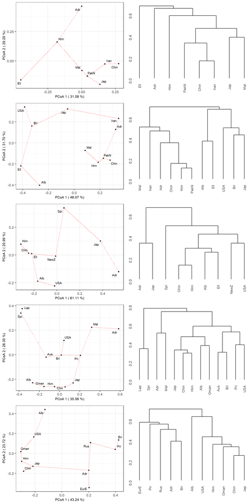

```r
Dice.Nosingle <- lapply(list.contingence.up2.Nosingle, function(data){
  distance <-
    labdsv::dsvdis(as.data.frame(t(data)),
                   index="sorensen",
                   step=0.0,diag=FALSE, upper=FALSE)
  # distance[which(distance==0)] <- 0.0000001
  return(distance)
})

Dice.Nosingle.up2 <- Dice.Nosingle

Dice.Nosingle.name <-list(
  Changhsingian = list(Changhsingian = Dice.Nosingle.up2$Changhsingian, name="Changhsingian"),
  Griesbachian = list(Griesbachian = Dice.Nosingle.up2$Griesbachian, name="Griesbachian"),
  Dienerian = list(Dienerian = Dice.Nosingle.up2$Dienerian, name="Dienerian"),
  Smithian = list(Smithian = Dice.Nosingle.up2$Smithian, name="Smithian"),
  Spathian = list(Spathian = Dice.Nosingle.up2$Spathian, name="Spathian"))

Multi_analysis <- function(data) {

  #PCOA
  pco_dice <- labdsv::pco(data[[1]],k=2)
  pco1 <- pco_dice$eig[1]/sum(pco_dice$eig)*100
  pco2 <- pco_dice$eig[2]/sum(pco_dice$eig)*100
  mst_pco_dice <- emstreeR::ComputeMST(pco_dice$points)

  g <- ggplot(data = mst_pco_dice, aes(x = V1, y = V2, from=from, to=to))+
    geom_point(size=1)+
    theme_bw()+
    theme(text=element_text(size=8),
          legend.title=element_text(size=8),
          legend.text=element_text(size=8),
          axis.title=element_text(size=8),
          axis.text=element_text(size=8))+
    # ggtitle(paste(data[[2]], "w/o singletons"))+
    stat_MST(colour="red")+
    geom_text_repel(aes(label=rownames(pco_dice$points)), size=2.5)+
    labs(y = paste("PCoA 2 (", format(round(pco2,2),nsmall=2), "%)"),
         x = paste("PCoA 1 (", format(round(pco1,2),nsmall=2), "%)"))

  #UPGMA
  UPGMA_dice <- stats::hclust(data[[1]], method = "average", members = NULL)
  d <- ggdendrogram(UPGMA_dice, rotate = FALSE, size = 2)+
    theme(axis.text.x = element_text(size = 8))

  #Graphic gathering
  ggarrange(g,d)
}

multi.analysis <- lapply(Dice.Nosingle.name, Multi_analysis)
multi.plot <- ggarrange(plotlist=multi.analysis,ncol=1,nrow=5)
multi.plot
```

```r
ggsave(file="PCoA_UPGMA_Dice_conodont_no singleton.svg", plot=multi.plot,
       width=100, height=200, units="mm")

#Get table of principal axes
VarexDice <- lapply(Dice.Nosingle.up2, function(data){
  pco_dice <- labdsv::pco(data,k=2)
  Var <- (pco_dice$eig/sum(pco_dice$eig))*100
}
)
Varex_Dice <- data.frame(lapply(VarexDice, "length<-", max(lengths(VarexDice))))
colnames(Varex_Dice) <- c("Changhsingian","Griesbachian","Dienerian","Smithian","Spathian")
Varex_Dice
```

```
##    Changhsingian  Griesbachian     Dienerian      Smithian      Spathian
## 1   3.157779e+01  4.607081e+01  6.111148e+01  3.555982e+01  4.324410e+01
## 2   2.928830e+01  3.170068e+01  2.099062e+01  2.629677e+01  2.372146e+01
## 3   1.941596e+01  8.110586e+00  1.460684e+01  1.994013e+01  1.348827e+01
## 4   1.438162e+01  6.156308e+00  9.238649e+00  1.178386e+01  1.072100e+01
## 5   3.701217e+00  5.463900e+00  6.046819e+00  4.153687e+00  7.340529e+00
## 6   2.158073e+00  3.862254e+00 -8.792122e-15  3.640369e+00  3.394794e+00
## 7   3.204823e-15  2.333207e+00 -7.292288e-01  1.983305e+00  2.410063e+00
## 8  -5.229630e-01  4.208352e-01 -4.899383e+00  1.313911e+00  1.082765e-15
## 9             NA  4.281825e-15 -6.365802e+00  8.197995e-01 -5.505491e-01
## 10            NA -7.539141e-01            NA  5.419636e-15 -9.569260e-01
## 11            NA -3.364666e+00            NA -9.501502e-02 -2.812736e+00
## 12            NA            NA            NA -1.843281e+00            NA
## 13            NA            NA            NA -3.553352e+00            NA
```

```r
write.csv2(x = Varex_Dice, file="PCoA axes_conodont.csv")

CoordDice <- lapply(Dice.Nosingle.up2, function(data){
  pco_dice <- labdsv::pco(data,k=2)
  pco.point <- pco_dice$points
}
)
```

### VI.c) BSN analyses

The BSN and associated graphical R functions have their own GitHub repository: https://github.com/PaulineGnsr/BSN_analysis

```r
#### BSN ANALYSIS ####
list.BSN.up2 <-list(Changhsingian = as.data.frame(t(list.contingence.up2.Nosingle$Changhsingian)),
                    Griesbachian = as.data.frame(t(list.contingence.up2.Nosingle$Griesbachian)),
                    Dienerian = as.data.frame(t(list.contingence.up2.Nosingle$Dienerian)),
                    Smithian = as.data.frame(t(list.contingence.up2.Nosingle$Smithian)),
                    Spathian = as.data.frame(t(list.contingence.up2.Nosingle$Spathian))
                    )

BSN <- function(data){
  ##2. Minimum Spanning Network (msn)
  paupau.quad <- function(data){
    dist <- labdsv::dsvdis(data, index="sorensen", step=0.0, diag=FALSE, upper=FALSE)
    # dist.S <- adespatial::dist.ldc(data, method="ab.simpson", binary=TRUE, samp=FALSE, silent=TRUE)
    # dist <- dist.D - dist.S

    df.dist <- metagMisc::dist2list(dist, tri=TRUE)
    colnames(df.dist) <- c("col","row","weight")
    df.dist$col <- as.character(df.dist$col)
    df.dist$row <- as.character(df.dist$row)

    df.dist.sort <- df.dist %>% dplyr::arrange(weight)
    df.dist.sort

    edg <- c()
    for (i in 1:nrow(df.dist.sort)) {
      #print(paste("i=",i))

      edg <- c(edg,
               df.dist.sort[i,1],df.dist.sort[i,2])

      if (rlang::is_empty(row.names(data)[!row.names(data) %in% edg])) {
        n <- length(edg)/2
        df.dist.sort.msn <- df.dist.sort[1:n,]
        msn <- igraph::graph_from_data_frame(df.dist.sort.msn, directed=FALSE)
      }
      else{next}

      if(igraph::is_connected(msn)==FALSE){next}
      else if (igraph::is_connected(msn)==TRUE){
        m <- max(which(df.dist.sort$weight==df.dist.sort$weight[i]))
      }
      break}
    msn.edgelist <- df.dist.sort[1:m,]
    msn.graph <- igraph::graph_from_data_frame(msn.edgelist, directed=FALSE)
  }

  graph.test <- paupau.quad(data)
  # plot(graph.test)
  # igraph::E(graph.test)$weight

  ##3. Boostrapping
  nboot <- 9999
  boot <- lapply(vector("list", nboot),
                 function(x){
                   boots <- sample(data, replace = TRUE)
                 }
  )
  boot.msn <- lapply(boot, paupau.quad)
  boot.msn <- c(list(graph.test), boot.msn)
  summary(as.factor(unlist(lapply(boot.msn, igraph::is_connected))))

  ##Calculate bootstrap values
  n <- vcount(graph.test)
  bootstrap_values <- matrix(0, nrow = n, ncol = n,
                             dimnames = list(V(graph.test)$name,
                                             V(graph.test)$name))
  for (i in 1:length(boot.msn)) {
    boot_msn_edges <- get.edgelist(boot.msn[[i]])
    for (j in 1:nrow(boot_msn_edges)) {
      bootstrap_values[boot_msn_edges[j, 1],
                       boot_msn_edges[j, 2]] <-
        bootstrap_values[boot_msn_edges[j, 1],
                         boot_msn_edges[j, 2]] + 1
    }
  }
  bootstrap_values <- bootstrap_values+t(bootstrap_values)
  bootstrap_values <- bootstrap_values / length(boot.msn)
  bootstrap_values[lower.tri(bootstrap_values)] <- NA
  bootstrap_values <- round(bootstrap_values, digits=3)

  ##Loop through edges of msn and assign bootstrap values
  amsn <- graph.test

  for (i in 1:length(E(amsn))) {
    from <- ends(amsn, E(amsn)[i])[1]
    to <- ends(amsn, E(amsn)[i])[2]
    E(amsn)$bootstrap[i] <- bootstrap_values[from, to]
  }

  # plot(amsn)
  # igraph::get.data.frame(amsn) %>% arrange(bootstrap)


  ##4. BSN
  cat("\n", "NEW BSN", "\n")
  amsn.df.sort <- igraph::as_data_frame(amsn) %>% dplyr::arrange(desc(bootstrap))
  amsn.sort <- igraph::graph_from_data_frame(amsn.df.sort, directed=FALSE)
  amsn.comp <- amsn.sort
  v <- make_empty_graph(directed = FALSE, n = vcount(amsn.sort)) %>% set_vertex_attr("name", value = V(amsn.sort)$name)
  n <- length(E(amsn))

    for(i in n:1){ #For each edge of the msn, from the weakest to the strongest bs
      amsn.df.sort <- igraph::as_data_frame(amsn.sort) %>% dplyr::arrange(desc(bootstrap))
      amsn.sort <- igraph::graph_from_data_frame(amsn.df.sort, directed=FALSE)
      sub.amsn <- delete_edges(amsn.sort, edges=E(amsn.sort)[i]) #Remove the edge and...

      #print(is_connected(sub.amsn))
      if (!is_connected(sub.amsn)  ){ #...evaluate the connectivity of the network
        cat( #A message appears if this edge is crucial for the network
          E(amsn.sort)[[i]],
          as_ids(E(amsn.sort)[[i]]),
          "WARNING DISCONNECTION: kept",
          "\n"
        )
        next
      }

      simp <- igraph::all_simple_paths(amsn.sort, amsn.df.sort[i,1], amsn.df.sort[i,2], cutoff=-1)
      len <- sapply(simp, length)
      simp.sort <- simp[order(len) - 1]

      comp <- as.vector(unlist(lapply(simp.sort, function(x){
        g <- make_empty_graph(directed = FALSE, n = vcount(amsn.sort)) %>% set_vertex_attr("name", value = V(amsn.sort)$name)
        g2 <- g + path(x)

        amsn.sort.sub <- #A subgraph of the msn is then computed with only the alternative path to keep the associated bs
          subgraph.edges(amsn.sort, eids=E(amsn.sort, P=as.vector(t(get.edgelist(g2)))), delete.vertices = TRUE)

        prod(E(amsn.sort.sub)$bootstrap) > E(amsn.sort)$bootstrap[i]
      })))

      if (length(which(comp==TRUE)) > 0){ #replace by TRUE
        l <- min(which(comp==TRUE))

        cat( #A message appears...
          i,
          as_ids(E(amsn.sort)[[i]]),
          "is",
          "weaker than",
          as_ids(simp.sort[[l]]),
          "(",l,"/",length(comp),")",
          "\n"
        )

        if(i==1){
          #print(i)
          amsn.sort <- delete_edges(amsn.sort, E(amsn.sort)[i])
          break
        }
        else if(E(amsn.sort)$bootstrap[i] == E(amsn.sort)$bootstrap[i-1]){
          v <- v + edge(amsn.df.sort[i,1], amsn.df.sort[i,2])
          #print(as_ids(E(v)))
        }
        else{
          v <- v + edge(amsn.df.sort[i,1], amsn.df.sort[i,2])
          #print(as_ids(E(v)))
          amsn.sort <- amsn.sort - v
        }
      }
      else{
        cat( #A message appears...
          i,
          "There is no stronger edge than",
          as_ids(E(amsn.sort)[[i]]),
          "nsimp =",length(comp),
          "\n"
        )
      }
    }

  #plot(amsn.sort)
  #get.data.frame(amsn.sort) %>% arrange(desc(bootstrap))
  return(amsn.sort)

}

multi.BSN <- lapply(list.BSN.up2, BSN)
```

```
##
##  NEW BSN
## 14 Mal|Ell is weaker than Mal Chin Iran PakN Ell ( 3 / 14 )
## 13 Chin|Adr WARNING DISCONNECTION: kept
## 12 PakN|Ell WARNING DISCONNECTION: kept
## 11 Iran|Him is weaker than Iran Chin Jap Mal Him ( 1 / 10 )
## 10 Iran|Jap is weaker than Iran Mal Chin Jap ( 1 / 10 )
## 9 Mal|Him WARNING DISCONNECTION: kept
## 8 PakN|Mal is weaker than PakN Chin Iran Mal ( 2 / 6 )
## 7 Jap|Chin is weaker than Jap Mal Chin ( 1 / 3 )
## 6 Mal|Jap WARNING DISCONNECTION: kept
## 5 There is no stronger edge than Iran|Mal nsimp = 2
## 4 There is no stronger edge than Mal|Chin nsimp = 2
## 3 PakN|Chin is weaker than PakN Iran Chin ( 1 / 2 )
## 2 Iran|PakN WARNING DISCONNECTION: kept
```

[output cut: 95 more lines]

```r
#Graphic representation
data.BSN <- list(Changhsingian = list(Changhsingian = multi.BSN$Changhsingian,
                                      coopco = CoordDice$Changhsingian,
                                      name="Changhsingian"),
                 Griesbachian = list(Griesbachian = multi.BSN$Griesbachian,
                                     coopco = CoordDice$Griesbachian,
                                     name="Griesbachian"),
                 Dienerian = list(Dienerian = multi.BSN$Dienerian,
                                  coopco = CoordDice$Dienerian,
                                  name="Dienerian"),
                 Smithian = list(Smithian = multi.BSN$Smithian,
                                 coopco = CoordDice$Smithian,
                                 name="Smithian"),
                 Spathian = list(Spathian = multi.BSN$Spathian,
                                 coopco = CoordDice$Spathian,
                                 name="Spathian")
                 )

graph.BSN <- function(data){

  width <- E(data[[1]])$bootstrap
  width[which(width==1)] <- 5.5
  width[which(width<1 & width>=0.9)] <- 4
  width[which(width<0.9 & width>=0.8)] <- 2.5
  width[which(width<0.8)] <- 1

  E(data[[1]])$width <- width

  colfuncV <- viridis# colorRampPalette(c("black","grey90"))#
  colfuncI <- viridis_pal(option="inferno", direction=-1)
  colors <- c(colfuncV(50), colfuncI(51))
  colors.weight <- colors[(E(data[[1]])$weight*100)+1]


  svg(filename=paste("BSN_conodont",data[[3]],".svg"), width = 10, height = 3)

  par(mfrow=c(1,3))
  #simple representation in a circle
  layout.circle <- layout_in_circle(data[[1]])
  plot.circle <-
    plot(data[[1]], layout=layout.circle, main=data[[3]],
         edge.color=colors.weight,
         vertex.size=5, vertex.color="black", vertex.frame.color=NA,
         vertex.label.color="black", vertex.label.size=5)

  #matching with pco axes
  coopco <- data[[2]][match(V(data[[1]])$name,
                            rownames(data[[2]])),]
  lo.pco <- norm_coords(coopco,
                        xmin=min(coopco[,1]), xmax=max(coopco[,1]),
                        ymin=min(coopco[,2]), ymax=max(coopco[,2]))
  plot.pcoa <-
    plot.igraph(data[[1]], rescale=F, layout=lo.pco, main="BSN vs PCoA",
                xlim = c(min(coopco[,1]), max(coopco[,1])),
                ylim = c(min(coopco[,2]), max(coopco[,2])),
                edge.color=colors.weight,
                vertex.size=1.5, vertex.color="black", vertex.frame.color=NA,
                vertex.label.color="black")

  #matching with paleocoord
  coord <- coord.mean.cent.ord[rownames(coord.mean.cent.ord)%in%V(data[[1]])$name,]
  coord <- coord[match(V(data[[1]])$name, rownames(coord)),]

  lo.coord <- norm_coords(as.matrix(coord),
                          xmin=min(coord$OffPaleolong), xmax=max(coord$OffPaleolong),
                          ymin=min(coord$OffPaleolat), ymax=max(coord$OffPaleolat))
  plot.palgeo <-
    plot.igraph(data[[1]], rescale=F, layout=lo.coord, main="BSN vs paleogeography",
                xlim = c(25, 381),
                ylim = c(-90, 90),
                edge.color=colors.weight,
                vertex.size=1.5, vertex.color="black", vertex.frame.color=NA,
                vertex.label.color="black")
  dev.off()

}

multi.graph.BSN <- lapply(data.BSN, graph.BSN)

#Save data table
data.BSN.table <- lapply(data.BSN, function(data){
  data.table <- igraph::as_data_frame(data[[1]])
  data.table <- data.table %>% tibble::rownames_to_column(var="Edge")
  colnames(data.table) <- c("Edge", "Region 1", "Region 2", "Dice index", "Bootstrap support")
  write.csv2(x = data.table, file=paste("BSN_data_conodont",data[[3]],".csv"), row.names = FALSE)
  return(data.table)
})
```